# Завдання 1.1

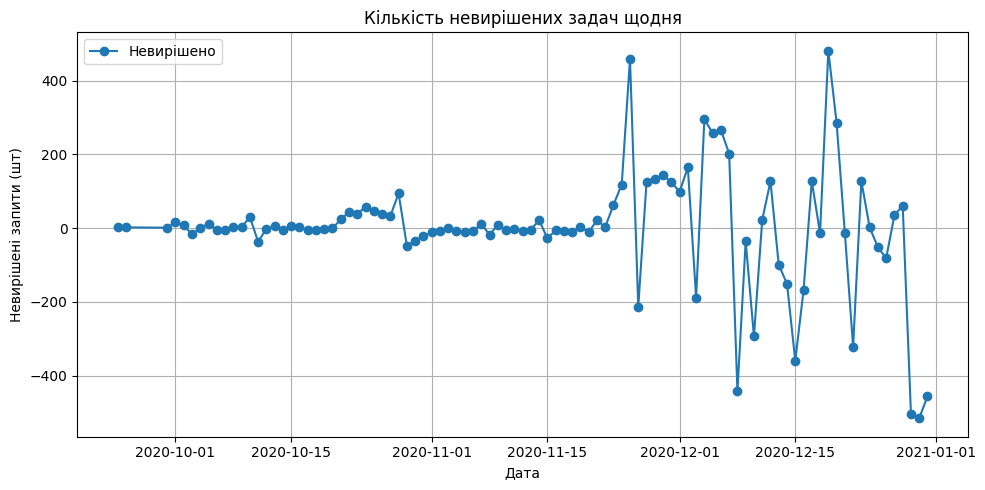

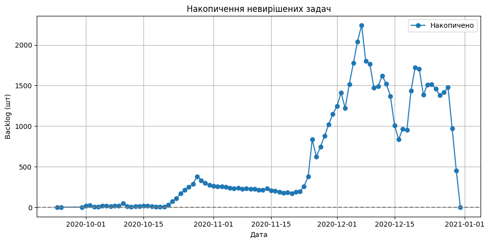

```python
# Підготовка дат
events_df["request_date"] = events_df["request_time"].dt.date
events_df["finish_date"] = events_df["finish_time"].dt.date

# Розрахунок кількості запитів і рішень на день
requests_per_day = events_df.groupby("request_date").size()
finishes_per_day = events_df.groupby("finish_date").size()

# Об'єднання в загальну таблицю
daily_summary = pd.concat([requests_per_day, finishes_per_day], axis=1).fillna(0)
daily_summary.columns = ["запитів", "вирішено"]

# Розрахунок залишку (невирішених задач)
daily_summary["невирішено"] = daily_summary["запитів"] - daily_summary["вирішено"]

# Побудова графіка: Невирішені задачі по днях
plt.figure(figsize=(10, 5))
plt.plot(daily_summary.index, daily_summary["невирішено"], marker='o', label="Невирішено")
plt.title("Кількість невирішених задач щодня")
plt.xlabel("Дата")
plt.ylabel("Невирішені запити (шт)")
plt.grid(True)
plt.tight_layout()
plt.legend()
plt.show()

# Аналіз накопичення backlog (кумулятивна сума)
daily_summary["накопичено"] = daily_summary["невирішено"].cumsum()

# Побудова графіка: Backlog
plt.figure(figsize=(10, 5))
plt.plot(daily_summary.index, daily_summary["накопичено"], marker='o', label="Накопичено")
plt.title("Накопичення невирішених задач")
plt.xlabel("Дата")
plt.ylabel("Backlog (шт)")
plt.axhline(0, color='gray', linestyle='--')
plt.grid(True)
plt.tight_layout()
plt.legend()
plt.show()
```

### Кількість невирішених задач щодня

Графік показує різницю між кількістю запитів, що надійшли, та кількістю вирішених протягом кожного дня.  
У період жовтня–листопада динаміка була стабільною: кількість нових задач приблизно відповідала кількості вирішених.

Починаючи з кінця листопада деякі дні показують різкий приріст запитів (+400+), інші — масове закриття задач (до -500).  
Це вказує на нерівномірне навантаження, можливі дії з масової обробки backlog або залежність від нерівномірного графіку роботи модераторів.

### Накопичення невирішених задач

Це свідчить про системну затримку з обробкою запитів, ймовірно через:

- перевищення кількості нових задач над можливістю їх обробки,
- нерівномірну активність команди або зменшення залученості модераторів. Рекомендовано:
- запровадити окрему команду або зміну для методичного очищення backlog,
- моніторити рівень накопичення на регулярній основі як ключову метрику

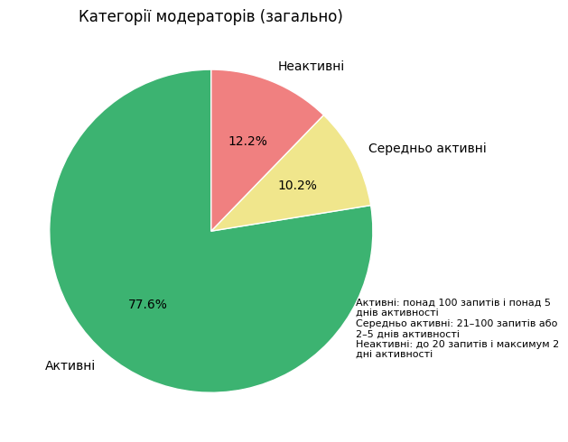

```python
moderator_stats = events_df.groupby("moderator").agg(
    total_requests=("id_request", "count"),
    avg_response_time=("response_time", "mean"),
    avg_handling_time=("handling_time", "mean"),
    active_days=("request_date", pd.Series.nunique)
).reset_index()

def categorize_moderator(row):
    if row["total_requests"] > 100 and row["active_days"] > 5:
        return "Активні"
    elif row["total_requests"] > 20 or row["active_days"] >= 2:
        return "Середньо активні"
    else:
        return "Неактивні"

moderator_stats["категорія"] = moderator_stats.apply(categorize_moderator, axis=1)
labels = ["Активні", "Середньо активні", "Неактивні"]
sizes = moderator_stats["категорія"].value_counts().reindex(labels, fill_value=0)
colors = ["mediumseagreen", "khaki", "lightcoral"]

plt.figure(figsize=(8, 5))
plt.pie(sizes, labels=labels, autopct='%1.1f%%', startangle=90,
        colors=colors, wedgeprops={"edgecolor": "white"})
plt.title("Категорії модераторів (загально)")

plt.figtext(0.7, 0.2,
    "Активні: понад 100 запитів і понад 5 днів активності\n"
    "Середньо активні: 21–100 запитів або 2–5 днів активності\n"
    "Неактивні: до 20 запитів і максимум 2 дні активності",
    wrap=True, horizontalalignment='left', fontsize=8)

plt.tight_layout()
plt.show()
```

# Активність модераторів

Це означає, що близько п’ятої частини наявної модераторської сили не використовується ефективно.  
Рекомендовано:

- активізувати менш залучених агентів або переглянути доцільність їх участі,
- оцінити можливість перерозподілу запитів між активними та менш активними модераторами.

# Відповіді на запитання та Рекомендації

### 1. Наскільки служба підтримки відповідає очікуванням менеджменту? Як вона працює зараз?

Служба **критично не відповідає очікуваному часу реагування (15–45 хв)**, однак **повністю відповідає вимогам щодо часу обробки задач після старту**.

### 2. На яких агентів варто звернути увагу задля підвищення якості обслуговування?

Більшість агентів демонструють **високу швидкість обробки**, проте:

- деякі агенти мають **надто низьку кількість опрацьованих запитів**;
- важливо проаналізувати, **чому частина агентів системно обирає лише "свіжі" задачі**, ігноруючи старі.

**Рекомендація:** ввести **рейтингову систему KPI**, що включає:

- середній час відповіді;
- середній час обробки;
- загальна кількість виконаних задач.

### 3. Чи варто збільшити команду підтримки? Якщо так — наскільки?

Проблема не стільки у нестачі людей, скільки в **нерівномірному розподілі навантаження**:

- майже **80% задач порушують часові межі реагування**;
- є агенти, які **за весь досліджуваний період закрили лише 1 задачу**. **Рекомендація:** не лише розширити команду, а й:
- **перерозподілити навантаження**;
- створити **спеціалізовану групу для опрацювання backlog**.

### 4. Як змінити графік роботи служби підтримки?

Так, графік потребує оптимізації:

- варто **підсилити ранкові та нічні години**;
- запровадити **спеціальний щоденний блок для очищення черги із застарілих задач**.

### 5. Чи є вигода від об'єднання команд?

Об’єднання команд `retail` та `wholesale` **не рекомендується**, оскільки:

- в них **різні темпи надходження задач**;
- існує ризик **втрати фокусу та пріоритетності**.

Краще зберегти поділ, але створити:

- **крос-командну підтримку для обробки backlog у вільні години**.

## Ключові рекомендації:

- Впровадити **принцип черги FIFO** для вирішення задач за часом надходження.
- Реорганізувати команду на два напрями:
  - **Оперативна група** — забезпечує швидке реагування на нові запити;
  - **Backlog-група** — методично обробляє старі задачі за принципом FIFO.